# Impact of the first goal

This analysis explores the impact of the first goal on the outcome of a match. Data taken from the 2018/19 premier league football season will show the frequency of goals scored by minutes, how often a team wins when they score first (split by home and away) and a teams result outcome based on the minute in which they score the first goal.

## How often do you win if you score the first goal?

**Figure 1: The result outcome of teams which score first in the 2018/19 Premier League football season**

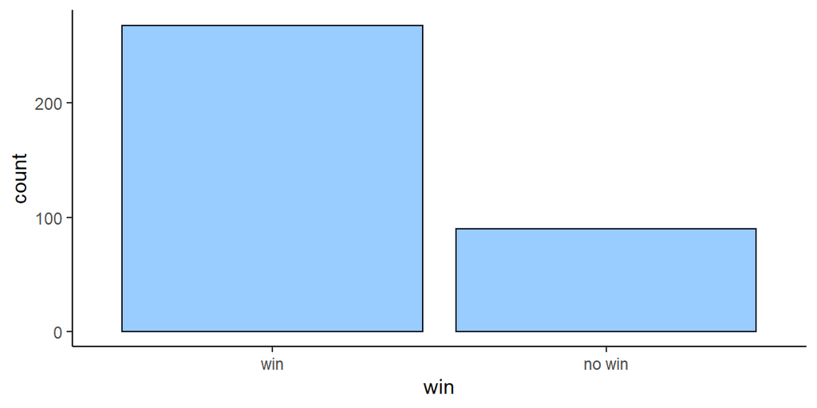

Of the 380 games in the 2018/19 Premier League season, 41% (156) of matches saw the home team score first and home team win. This season also saw 29% (112) of matches where the away team would score first and the away team win. This is demonstrated in figure 2 below.

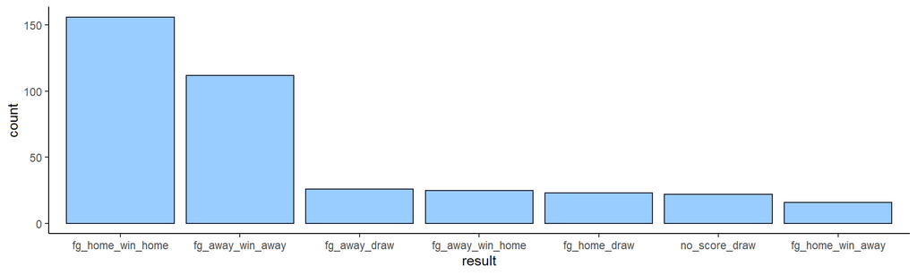

There were 195 matches (51%) where the home team scored first in the 2018/19 Premier League season. Of these 195 matches, 80% (156) of the time the home team would win.The proportion of matches in which the home team would score first and lose was only 8% (16) and 12% (23) of matches saw the home team score first and draw.

There were 163 matches (43%) where the away team scored first in the 2018/19 Premier League season. Of the 163 matches, 69% (112) of the time the away team would win. This is 11 percentage points lower than when a home team scores the first goal. The proportion of matches in which the away team would score first and lose was 15% (25) and 16% (26) of matches saw the away team score first and draw.

## When is the most frequent time a goal is scored during a match?

Our data shows that the most common time for a team to score their first goal were in the 5th, 10th, 11th and 24th minute of a match, with 11 goals scored in each of those minutes. Just over a quarter of first goals (26%) were scored in the first 11 minutes of matches and just over half of the first goals scored (53%) were scored in the first 24 minutes of matches.

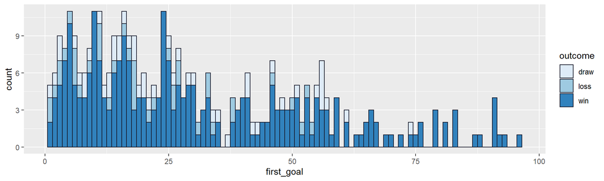